# Quiz 1: Part 2

## Part 2: Coding in action

### Instructions

Please answer these questions in R using whatever syntax makes sense to you. Feel free to use the R help pages and/or notes from class.

**If you use Google or ChatGPT etc. to help you get to an answer, please note so on your answer**

Step 1. ARE YOU IN A BRANCH?????  
Step 2. Save this file as lastname_quiz.qmd in the same quiz folder.  
Step 3. Once you are done, click “render” above. This will create the .html file that I will evaluate.  
Step 4. Stage and commit your changes, push to your github.  
Step 5. Submit a pull request. If github warns you of conflicts please try and fix them before submitting your pull request (did you rename the file??? ).  
(Step 6. In case of utter disaster, email Sabrina your .html file.)

```r
# load packages and data
library(ggplot2)
library(dslabs)
library(dplyr)
library(readr)
library(patchwork)
```

#### Load your data:

Load the *swallows.csv* into R, call it swallows. This data frame lists results of an experiment on tree swallows. Each row is a nest. Nests were put into one of two **treatments**: simulated predation (predator), or control (control). Along with treatment you have the following columns:  
**nest_fate** = whether the nest fledged any young or whether they all died  
**brood** = number of nestlings  
**n_fledged** = number of nestlings that fledged.

You also have a separate data frame called *brightness.csv* where each row lists the plumage brightness (a sexual signal) for the female at each nest. Load this one up too.

```r
# Type your answer in this box using R code
#swallows <- read.csv(file.choose(~swallows.csv))
#brightness_swal <- read.csv(file.choose(~brightness.csv))
swallows <- read.csv("swallows.csv")
brightness_swal <- read.csv("brightness.csv")

# Google? No
```

#### Wrangle your data

```r
#Answer
class(swallows$nestbox)
```

```
[1] "character"
```

```r
class(brightness_swal$nestbox)
```

```
[1] "character"
```

```r
swallows_joined <- swallows %>%
  left_join(
    brightness_swal %>%
      select(nestbox, brightness) %>%
      distinct(nestbox, .keep_all = TRUE),
    by = "nestbox"
  )

#check join worked
#compare a random set of nest boxes to ensure that the correct brightness value was ascribed to the right swallow based on their nest box
filter(swallows, nestbox %in% c("2_109","4_80","2_32","1_85","4_62"))
```

```
  nestbox treatment brood n_fledged
1   2_109 Predation     5         2
2    4_80   Control     5         5
3    4_62 Predation     6         2
4    1_85   Control     4         2
5    2_32 Predation     2         0
```

```r
filter(brightness_swal, nestbox %in% c("2_109","4_80","2_32","1_85","4_62"))
```

```
  brightness nestbox
1       57.0    1_85
2         NA   2_109
3       52.6    2_32
4       57.4    4_62
5       43.8    4_80
```

```r
filter(swallows_joined, nestbox %in% c("2_109","4_80","2_32","1_85","4_62"))
```

```
  nestbox treatment brood n_fledged brightness
1   2_109 Predation     5         2         NA
2    4_80   Control     5         5       43.8
3    4_62 Predation     6         2       57.4
4    1_85   Control     4         2       57.0
5    2_32 Predation     2         0       52.6
```

```r
#count number of observations of different nestboxes to ensure no duplicates happened to nestboxes upon joining
count(swallows_joined, nestbox)
```

```
   nestbox n
1    1_104 1
2     1_12 1
3    1_121 1
4    1_123 1
5     1_17 1
6     1_62 1
7     1_81 1
8     1_85 1
9     1_91 1
10   2_102 1
11   2_105 1
12   2_109 1
13   2_114 1
14   2_117 1
```

[output cut: 28 more lines]

```r
#Google? Yes, looked up how to perform a left join.
```

Inspect your combined data frame. Do some sort of quick sanity check on each column to catch any obvious entry errors. Correct as necessary

```r
# Answer
#general check on column presence
head(swallows_joined)
```

```
  nestbox treatment brood n_fledged brightness
1   2_124   Control     6         2       58.4
2    2_22   Control     5         5       57.7
3   2_109 Predation     5         2         NA
4     2_8   Control     5         3       55.7
5    2_12   Control     6         6       58.6
6    2_14 Predation     3         2       54.2
```

```r
#general check on class of each variable
str(swallows_joined)
```

```
'data.frame':   42 obs. of  5 variables:
 $ nestbox   : chr  "2_124" "2_22" "2_109" "2_8" ...
 $ treatment : chr  "Control" "Control" "Predation" "Control" ...
 $ brood     : int  6 5 5 5 6 3 4 5 5 5 ...
 $ n_fledged : int  2 5 2 3 6 2 4 5 1 4 ...
 $ brightness: num  58.4 57.7 NA 55.7 58.6 54.2 41.5 39.9 49.3 68 ...
```

```r
#check for na
sum(is.na(swallows_joined$nestbox))
```

```
[1] 0
```

```r
sum(is.na(swallows_joined$treatment))
```

```
[1] 0
```

```r
sum(is.na(swallows_joined$brood))
```

```
[1] 0
```

```r
sum(is.na(swallows_joined$n_fledged))
```

```
[1] 0
```

```r
sum(is.na(swallows_joined$brightness))
```

```
[1] 1
```

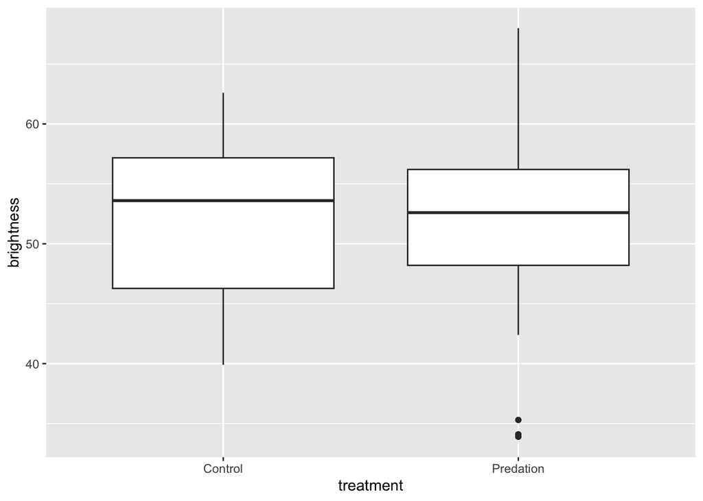

```r
#identified one na in brightness
brightness_corrected <- swallows_joined |> filter(brightness != is.na(brightness))

ggplot(brightness_corrected, aes(treatment, brightness))+
  geom_boxplot()
```

```r
#shows low brightness values in predation category
filter(brightness_corrected, brightness < 40)
```

```
  nestbox treatment brood n_fledged brightness
1    2_38   Control     5         5       39.9
2   1_121 Predation     6         2       33.9
3   2_121 Predation     6         3       34.1
4   1_104 Predation     0         0       35.3
```

```r
summarize(brightness_corrected, avg = mean(brightness), deviation = sd(brightness))
```

```
       avg deviation
1 51.19756  8.126176
```

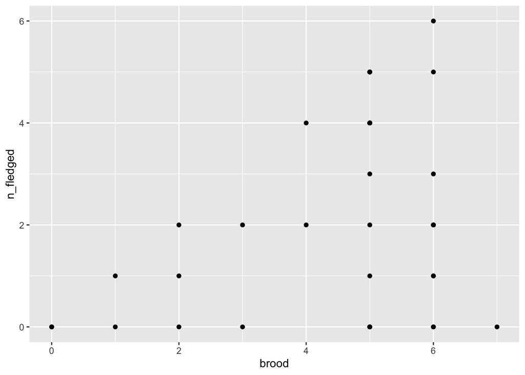

```r
#three points are more than 2 standard deviations away, but don't seem like error values

ggplot(brightness_corrected, aes(brood, n_fledged))+
  geom_point()
```

```r
#nothing unusual

#check that there are no observations where n_fledged is greater than the brood size originally
filter(brightness_corrected, n_fledged > brood)
```

```
[1] nestbox    treatment  brood      n_fledged  brightness
<0 rows> (or 0-length row.names)
```

```r
#there are not

# Google? No
```

Create a new column called prop_fledged that contains the proportion of nestlings that fledged from each nest.

```r
#Answer
swallows_data <- brightness_corrected |> mutate(prop_fledged = n_fledged/brood)
str(swallows_data$prop_fledged)
```

```
 num [1:41] 0.333 1 0.6 1 0.667 ...
```

```r
# Google? No
```

#### Explore the data

What was the mean proportion of nestlings fledged in each treatment?

```r
# Answer
#filter out NaN
swallows_data_2 <- swallows_data |> filter(prop_fledged != is.nan(prop_fledged))
#It was being finicky, so eliminating 0 as the brood size instead so it doesn't return not a number
swallows_data <- brightness_corrected |> filter(brood != 0) |> mutate(prop_fledged = n_fledged/brood)

swallows_data |>
  group_by(treatment) |>
  summarise(avg_prop_fledged = mean(prop_fledged))
```

```
# A tibble: 2 × 2
  treatment avg_prop_fledged
  <chr>                <dbl>
1 Control              0.706
2 Predation            0.332
```

```r
#Control: 0.7055556
#Predation: 0.3316667

# Google? No, because I got it working without googling. But yes, because I got curious why the is.nan function wasn't working. It wanted the syntax: filter(!is.nan(prop_fledged))
```

Create a plot showing fledging success differences between treatments

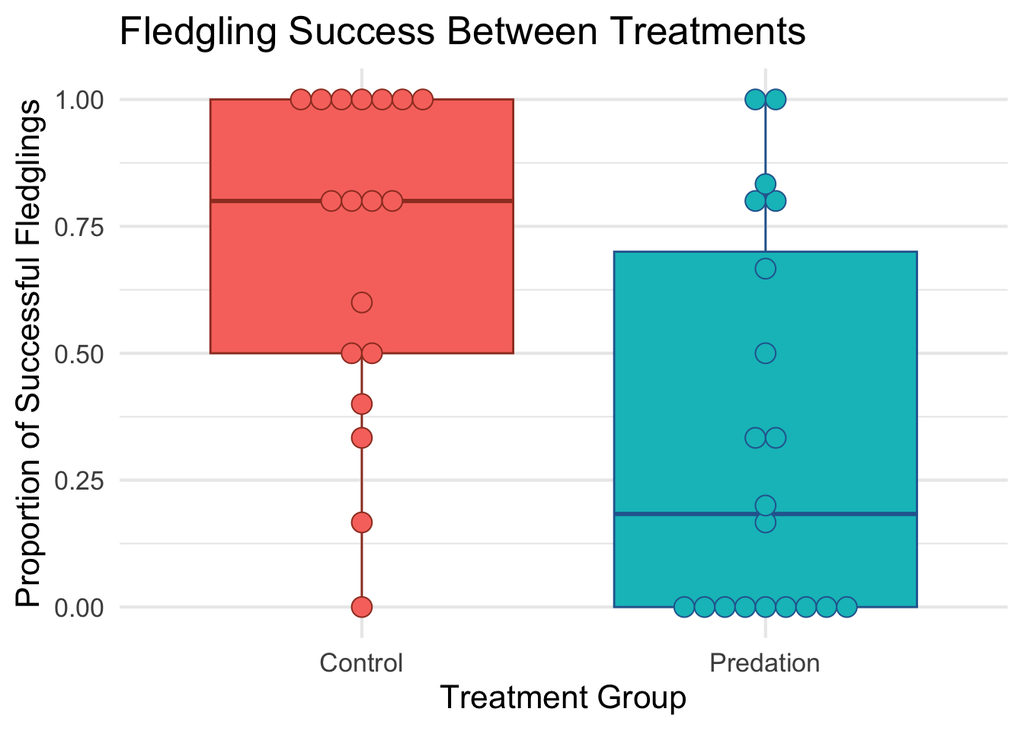

```r
# Answer
dark_col <- c("#9E3C29","#29679E")

ggplot(swallows_data, aes(treatment, prop_fledged, fill = treatment, color = treatment))+
  geom_boxplot()+
  labs(
    title = "Fledgling Success Between Treatments",
    x = "Treatment Group",
    y = "Proportion of Successful Fledglings",
  )+
  scale_color_manual(values = dark_col)+
   geom_dotplot(binaxis='y', stackdir='center', dotsize=2, binwidth = .02)+
  theme_minimal(base_size = 16)+
  theme(
    legend.position = "none")
```

```r
# Google? Yes, specifications for graph like size and colors and how to overlay data points onto a boxplot
```

Is there any evidence that female brightness influenced fledging success? Create a plot to visually investigate this question.

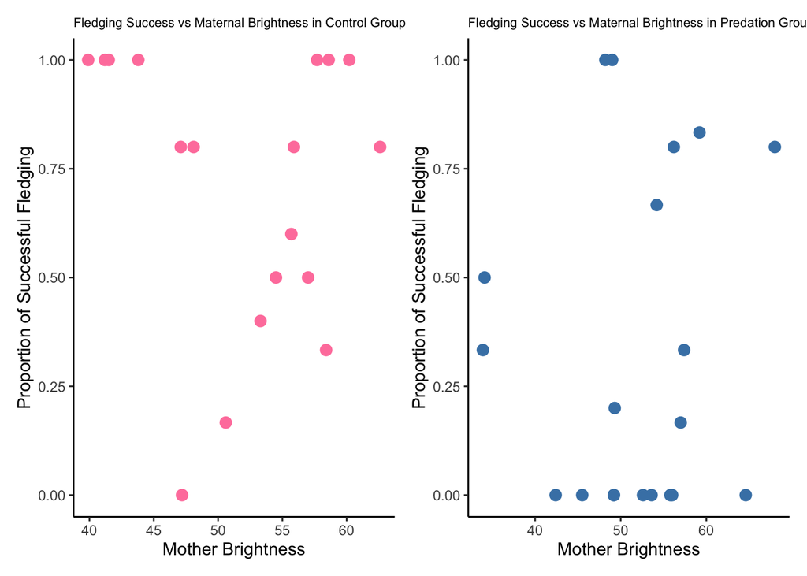

```r
# Answer (I answered with several graphs, because I wanted to see the effects of brightness independent of treatment group first)

control_data <- swallows_data |> filter(treatment == "Control")
predation_data <- swallows_data |> filter(treatment == "Predation")

plot_cont <- ggplot(control_data, aes(brightness, prop_fledged))+
  geom_point(color = "palevioletred1", size = 3)+
  labs(
    title = "Fledging Success vs Maternal Brightness in Control Group",
    x = "Mother Brightness",
    y = "Proportion of Successful Fledging"
  )+
  theme_classic(base_size = 11)+
  theme(plot.title = element_text(size = 8), legend.position = "none")

plot_pred <- ggplot(predation_data, aes(brightness, prop_fledged))+
  geom_point(color = "steelblue", size = 3)+
   labs(
    title = "Fledging Success vs Maternal Brightness in Predation Group",
    x = "Mother Brightness",
    y = "Proportion of Successful Fledging"
   )+
  theme_classic(base_size = 11)+
  theme(plot.title = element_text(size = 8), legend.position = "none")

plot_cont + plot_pred
```

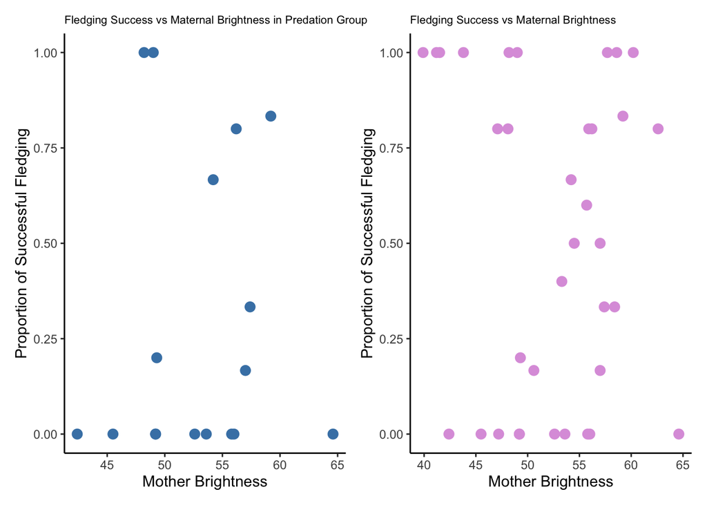

```r
#omiting the outliers 2 standard deviations away and doing a combined graph
swallows_data_omit <- swallows_data |> filter(brightness > 35) |> filter(brightness < 67)
predation_data_2 <- swallows_data |> filter(treatment == "Predation") |> filter(brightness > 35) |> filter(brightness < 67)

plot_pred_cor <- ggplot(predation_data_2, aes(brightness, prop_fledged))+
  geom_point(color = "steelblue", size = 3)+
   labs(
    title = "Fledging Success vs Maternal Brightness in Predation Group",
    x = "Mother Brightness",
    y = "Proportion of Successful Fledging"
   )+
  theme_classic(base_size = 11)+
  theme(plot.title = element_text(size = 8), legend.position = "none")

plot_combined <- ggplot(swallows_data_omit, aes(brightness, prop_fledged))+
  geom_point(color = "plum", size = 3)+
   labs(
    title = "Fledging Success vs Maternal Brightness",
    x = "Mother Brightness",
    y = "Proportion of Successful Fledging"
   )+
  theme_classic(base_size = 11)+
  theme(plot.title = element_text(size = 8), legend.position = "none")

plot_pred_cor + plot_combined
```

```r
# Google? Yes for placing graphs next to each other and resizing titles
```